# Pre-oligotyping diagnostics for functional genes

Marina Zure and Antonio Fernandez-Guerra

February 29, 2016

**How to decide if we should keep the third codon position if we want to perform an oligotyping analysis on functional genes**

In the following example, we use the *acsA* (acetyl-coenzyme A synthetase) gene data from *Rhodopirellula* species used in Zure et al. 2016 used to perform a Minimum Entropy Decomposition ([MED](http://merenlab.org/projects/med/)) analysis, the unsupervised flavour of [oligotyping](http://merenlab.org/projects/oligotyping/).

In case we don’t have the package installed:

```r
install.packages("devtools")
library(devtools)
install_github("genomewalker/oligo4fun")
```

```
## Installing oligo4fun
```

```
## Skipping 6 packages ahead of CRAN: BatchJobs, digest, R6, Rcpp, sp, tidyr
```

[output not shown]

Then we load the package:

```r
library(oligo4fun)
```

Let’s have a look at the data, first at the entropy file:

```r
data(entropy)
entropy
```

```
## Source: local data frame [483 x 2]
##
##       V1     V2
##    (int)  (dbl)
## 1    413 1.4098
## 2    269 1.3759
## 3    218 1.3265
## 4    299 1.3041
## 5    419 1.2751
## 6    263 1.2687
## 7    260 1.1766
## 8    329 1.1619
## 9    275 1.0633
## 10   449 1.0600
## ..   ...    ...
```

and then at the MED input alignment file:

```r
data(aln)
aln
```

```
## 361890 DNA sequences in binary format stored in a matrix.
##
## All sequences of same length: 483
##
## Labels: Sample-101_Read10 Sample-101_Read19 Sample-101_Read55 Sample-101_Read72 Sample-101_Read90 Sample-101_Read105 ...
##
## More than 1 million nucleotides: not printing base composition
```

One can read any fasta file using “read.dna” function from [ape](https://cran.r-project.org/web/packages/ape/index.html) package:

```r
aln <- read.dna(file=file, format = "fasta", as.character=FALSE, skip=0)
```

First we will explore the entropy value distribution on all codon positions:

```r
entropy_plot <- plot_entropy_density(entropy)
```

```
## Note: Entropy dataframe has been processed
```

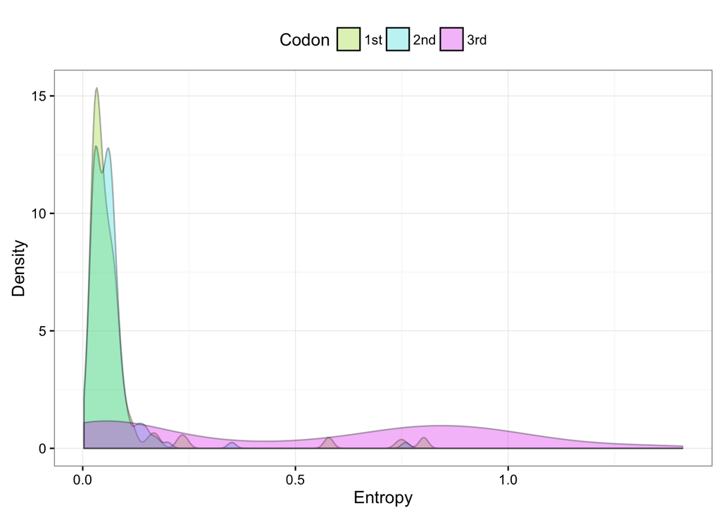

```r
entropy_plot
```

The resulting plot shows that the 3rd codon position has higher entropy values. This suggests that if we use this aligment as input for MED it could result in a possible overestimation of the diversity.

The next step is about getting to know if the higher entropy values imply a real change in the aminoacid sequence or are silent substitution. We will use a saturation plot to explore the transitions and transversions ratio. As the NGS datasets that can be used for MED are really large, in this example we will pick 500 random sequences for the analysis (we recommend to use >5000 sequences). For the distance calculation we use the *Kimura’s 2-parameters distance* (K80). We set **all = FALSE** because we only want to focus on the 3rd codon position, we can calculate the ratio for all codon positions with **all = TRUE**.

```r
saturation_estimate <- estimate_saturation(aln, nseqs = 500, model = "K80", all = FALSE )
```

```
## Note: A random seed has been selected
## Seed used: 1376112
## Randomly selected 500 sequences
##
## Sequence alignment cointaining only the 3rd codon position
## Calculating the number of pairwise transitions and transversions
## Computing matrix of pairwise distances using model K80
## Calculating statistics
## Drawing saturation plot
## Results suggests that there is saturation
## Removing 3rd codon position to the alignment
## Note: Substitution saturation occurs when the frequency of transitions (mean:23.02) overtakes the frequency of transversions (mean:12.19)
```

We can visually inspect the saturation plot:

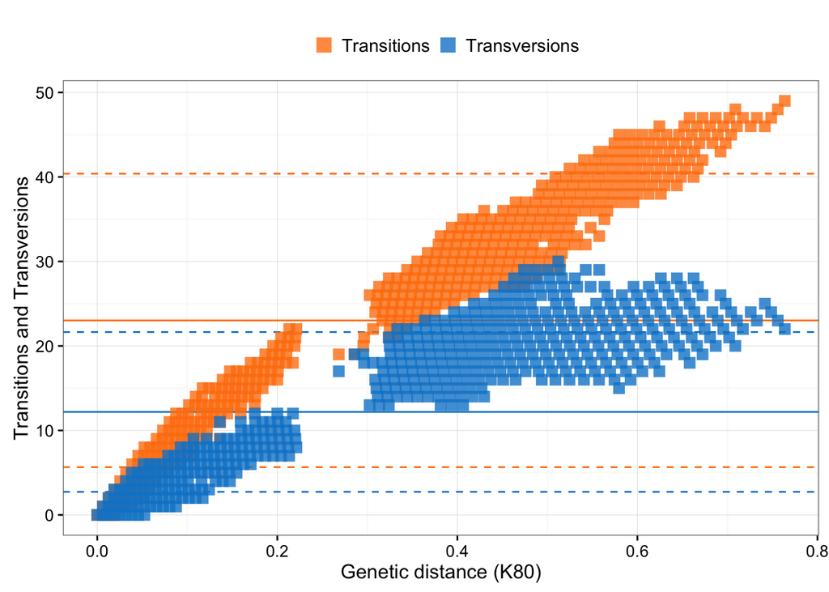

```r
saturation_estimate$plot
```

Get some statistics:

```r
saturation_estimate$stats
```

```
## $mean_ti
## [1] 23.01783
##
## $sd_ti
## [1] 17.36827
##
## $mean_tv
## [1] 12.18915
##
## $sd_tv
## [1] 9.456685
```

Or get the alignment without the 3rd codon position which can be used for the MED analysis:

```r
saturation_estimate$aln_no_3rd
```

```
## 361890 DNA sequences in binary format stored in a matrix.
##
## All sequences of same length: 322
##
## Labels: Sample-101_Read10 Sample-101_Read19 Sample-101_Read55 Sample-101_Read72 Sample-101_Read90 Sample-101_Read105 ...
##
## More than 1 million nucleotides: not printing base composition
```

But using only 500 or 5000 sequences is not enough to be sure that there is no substitution saturation in our alignment. In this case one can use the function **estimate_saturation_n** to perform n random subsamplings of the main alignment file. An example using the sequential version performing 10 random subsamplings of 500 sequences:

```r
random_saturation_estimates <- estimate_saturation_n(aln, rep = 10, nseqs = 500, model = "K80", parallel = FALSE, all = FALSE, save_alns = FALSE)
```

```
## |++++++++++++++++++++++++++++++++++++++++++++++++++++++++++++++++++++++++++++++++| 100%
```

For a real world analysis we would perform at least 100 random subsamplings of >5000 sequences. The parallel version uses BatchJobs to distribute the different random subsamplings over multiple cores or a computer cluster. An example using the different cores of a computer:

```r
random_saturation_estimates <- estimate_saturation_n(aln, rep = 10, nseqs = 500, model = "K80", parallel = TRUE, all = FALSE, save_aln = FALSE, conf_file = "~/.BatchJobs.R", reg_id = "rhodo", reg_dir = "~/rhodo_dir", keep_reg = FALSE)
```

```
## Creating dir: ~/rhodo_dir
```

```
## Sourced 2 configuration files:
```

```
##   1: /Library/Frameworks/R.framework/Versions/3.2/Resources/library/BatchJobs/etc/BatchJobs_global_config.R
```

```
##   2: /Users/ufo/.BatchJobs.R
```

[output not shown]

```
## Saving registry: /Users/ufo/rhodo_dir/registry.RData
```

```
## Adding 10 jobs to DB.
```

```
## Saving conf: /Users/ufo/rhodo_dir/conf.RData
```

```
## Submitting 10 chunks / 10 jobs.
```

```
## Cluster functions: Multicore.
```

```
## Auto-mailer settings: start=none, done=none, error=none.
```

```
## Sending 10 submit messages...
## Might take some time, do not interrupt this!
```

```
## 7 temporary submit errors logged to file '/Users/ufo/rhodo_dir/submit.log'.
## First message: Multicore busy: L
```

```
## Syncing registry ...
```

```
## Reducing 10 results...
```

```
## Status for 10 jobs at 2016-03-02 15:49:30
## Submitted: 10 (100.00%)
## Started:   10 (100.00%)
## Running:    0 (  0.00%)
## Done:      10 (100.00%)
## Errors:     0 (  0.00%)
## Expired:    0 (  0.00%)
## Time: min=9.00s avg=16.60s max=20.00s
```

> For reproducibility purposes, all seeds used by **estimate_saturation** and **estimate_saturation_n** are stored in the object returned under **seed**.

> We also recommend to set **save_alns = FALSE** as it can produce a large IO load when using a large number of iterations

The contents of the **.BatchJobs.R** file:

```r
cluster.functions = makeClusterFunctionsMulticore(ncpus = max(getOption("mc.cores", parallel::detectCores()) - 1L, 1L))
staged.queries = TRUE
debug = FALSE
```

You can find examples for other queue managers [here](https://github.com/tudo-r/BatchJobs/tree/master/examples/). For example, if our cluster uses SGE, our **.tmpl** file should be similar to this [here](https://github.com/tudo-r/BatchJobs/blob/master/examples/cfSGE/simple.tmpl) and the **.BatchJobs.R** file should contain:

```r
cluster.functions = makeClusterFunctionsSGE("simple.tmpl")
staged.queries = TRUE
debug = FALSE
```

Once we got the results, we can explore the returned object. We can explore the combined statistics:

```r
random_saturation_estimates$combined_stats
```

```
## Source: local data frame [10 x 4]
##
##     mean_ti    sd_ti  mean_tv    sd_tv
##       (dbl)    (dbl)    (dbl)    (dbl)
## 1  23.34313 17.59591 12.36005 9.572586
## 2  22.61843 17.52720 11.98275 9.603165
## 3  21.76359 17.43766 11.37730 9.545728
## 4  22.63791 17.50658 11.89146 9.588195
## 5  22.03190 17.09155 11.57948 9.382785
## 6  22.22527 17.31354 11.82006 9.529700
## 7  22.90797 17.37829 12.26666 9.616049
## 8  21.55975 17.14403 11.40653 9.527593
## 9  22.30829 17.17119 11.62052 9.363744
## 10 20.59689 17.84109 10.80402 9.673496
```

Or we can look at the distribution of the average values for transitions and transversion for all random subsamplings:

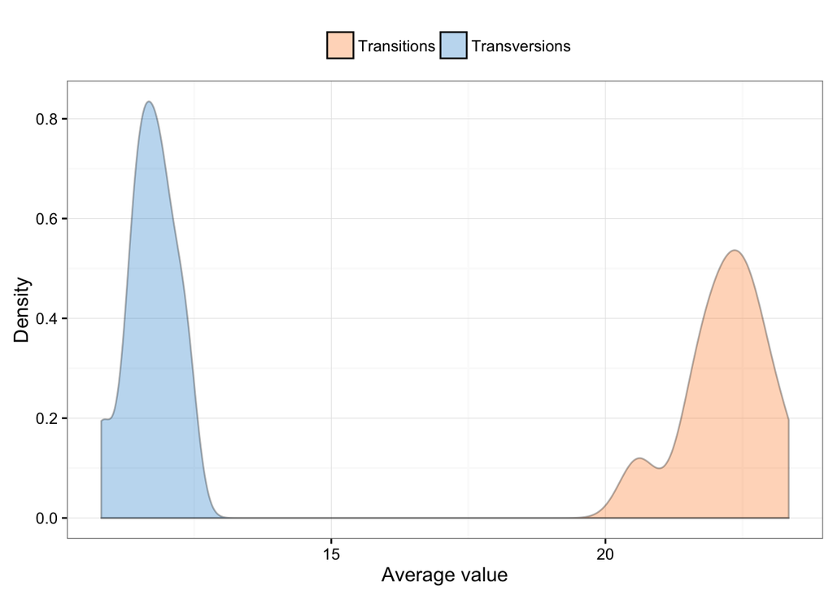

```
## Plots written to  ~/saturation_test_alignment_density_030220161549.pdf
```

```r
write_saturation_plot_density(random_saturation_estimates, dir = "~", format = "pdf", show = TRUE)
```

This plot also suggests that there are more transitions than transversions so it would be recommendable to remove the 3rd codon position from the alignment.

We can easily do this:

```r
write_saturation_alignments(random_saturation_estimates, dir = "~", no3rd = TRUE)
```

```
## Saving original alignment without the 3rd codon position
## Alignment(s) written to ~/saturation_test_alignment_no3rd_030220161549.fasta
```

We can save all plots on disk:

```r
write_saturation_plots(random_saturation_estimates, dir = "~", format = "pdf")
```

```
## Saving saturation plots from multiple alignment random subsamplings
```

```
## |++++++++++++++++++++++++++++++++++++++++++++++++++++++++++++++++++++++++++++++++| 100%
```

```
## Plot(s) written to  ~
```

And all random alignments used:

```r
write_saturation_alignments(random_saturation_estimates, dir = "~")
```

```
## Saving random alignments used for the saturation estimation
```

```
## |++++++++++++++++++++++++++++++++++++++++++++++++++++++++++++++++++++++++++++++++| 100%
```

```
## Alignment(s) written to  ~
```

After all these steps we can use the exported alignment for the [MED](http://merenlab.org/projects/med/) analysis.

For any questions realted to **oligo4fun** open a new issue [here](https://github.com/genomewalker/oligo4fun/issues)